# Predicting Depression in University Students: The Role of Anxiety

Parsa Rismanchi

2025-11-08

## 1 Abstract

Analysis of a public student mental-health dataset (**n = 101**) shows higher depression rates among anxious students compared with non-anxious peers. Using descriptive statistics, a two-proportion (χ²) test, and a logistic regression, we find a substantially higher odds of depression for students reporting anxiety. Results are reported with effect sizes and confidence intervals; all materials are fully reproducible.

## 2 1. Introduction

**Aim/Hypothesis.** Anxiety is associated with higher depression risk among university students.  
This mini project is a **replication with small extensions** using a public dataset (Islam, 2023; Kaggle).

## 3 2. Methods

**Data Source.** Kaggle: *Student Mental Health Dataset* (Shariful Islam, 2023).  
**Variables.** Anxiety (Yes/No), Depression (Yes/No) — recoded to 1/0.  
**Exclusions.** Rows with missing Anxiety/Depression removed.  
**Analysis.** Descriptive rates by anxiety status; two-proportion test (χ²); logistic regression with odds ratio (OR) and 95% CI.

## 4 3. Results

Table 1. Percentage of Depressed Students by Anxiety Status (n = 101)

| Anxiety Status | Depressed (n) | Group Size (n) | Percent Depressed |
| --- | --- | --- | --- |
| Not Anxious | 17 | 67 | 25.4 |
| Anxious | 18 | 34 | 52.9 |

**Key Finding.**  
- **52.9%** of anxious students were depressed  
- **25.4%** of non-anxious students were depressed

**Statistical Test (APA-style).**  
χ²(1) = 6.40, *p* = .0114; OR = 3.31, 95% CI [1.40, 8.03], *p* = .007.

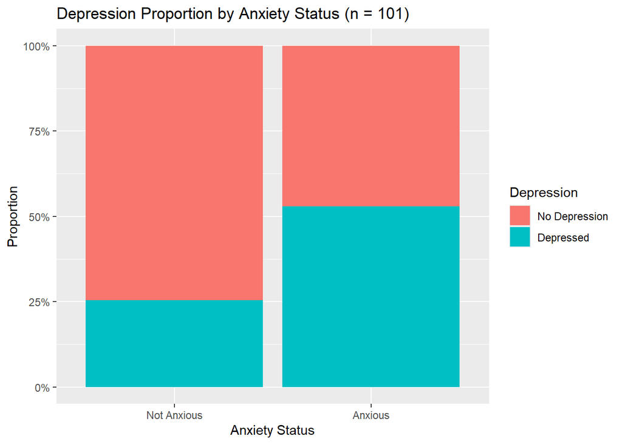

## 5 4. Discussion

Findings replicate the expected association: anxious students show higher depression rates.  
**Limitations.** Secondary, cross-sectional, self-report; no causal inference.  
**Implications.** Routine anxiety screening may help identify students at higher risk.

## 6 5. Conclusion

Anxiety is associated with higher odds of depression in this student sample. Reporting emphasizes effect sizes (OR, CI) and reproducibility.

## 7 References

Islam, S. (2023). *Student Mental Health Dataset*. Kaggle. (See dataset page for access and license details; accessed 08 November 2025.)

## 8 Reproducibility & Integrity

This is an **independent replication study** using a public dataset (Islam, 2023).  
All code, analysis, and reporting were conducted by **Parsa Rismanchi**.  
No part of this work was copied from existing notebooks.  
Full reproducibility is ensured via the provided R Markdown file and session info below.

## 9 Data Availability

- **Source:** Kaggle – Student Mental Health (Shariful Islam, 2023)
- **License:** See dataset page for license details
- **Ethics:** Public anonymized data; no human-subjects involvement

[session information not shown]